# Clusters Analysis in R - kmeans() and hclust()

Created By Julio SOLANO

Oct 20, 2018

# Setup

```r
 set.seed(69069)
```

# Loading Libraries

```r
library(car)              # DavisThin dataset
library(cluster)          # clusplot function
library(fpc)              # pam function
library(kableExtra)


# Organizing Packge information for table
packages <- c("car", "cluster", "fpc", "kableExtra")
display <- c("Package","Title", "Maintainer", "Version", "URL")
table <- matrix(NA, 1, NROW(display), dimnames = list(1, display))
for(i in 1:NROW(packages)){
list <- packageDescription(packages[i])
table <- rbind(table, matrix(unlist(list[c(display)]), 1, NROW(display), byrow = T))
}
table[,NROW(display)] <- stringr::str_extract(table[,NROW(display)], ".+,")

# Table of packages
kable(table[-1,], format = "html", align = "c") %>%
  kable_styling(bootstrap_options = c("striped", "hover", "condensed"))
```

|  | Package | Title | Maintainer | Version | URL |
| --- | --- | --- | --- | --- | --- |
|  | car | Companion to Applied Regression | John Fox <jfox@mcmaster.ca>; | 3.0-0 | https://r-forge.r-project.org/projects/car/, |
|  | cluster | “Finding Groups in Data”: Cluster Analysis Extended Rousseeuw et al. | Martin Maechler <maechler@stat.math.ethz.ch>; | 2.0.7-1 | NA |
|  | fpc | Flexible Procedures for Clustering | Christian Hennig <c.hennig@ucl.ac.uk>; | 2.1-11 | NA |
|  | kableExtra | Construct Complex Table with ‘kable’ and Pipe Syntax | Hao Zhu <haozhu233@gmail.com>; | 0.9.0 | http://haozhu233.github.io/kableExtra/, |

# Problem Definition

En los siguientes ejercicios trataremos el análisis de conglomerados. Usaremos R para implementar el algoritmo k-means (k-medias) para el análisis de conglomerados y el conjunto de datos DavisThin. Este set de datos tiene 191 filas y 7 columnas y está incluido en el paquete car. Estos datos son parte de un conjunto de datos más grande para un estudio de trastornos de alimentación. Las siete variables en el marco de datos comprenden una escala de “unidad para delgadez”, que se conformó sumando ciertos elementos durante una investigación.

# Exercise 1: Data Source

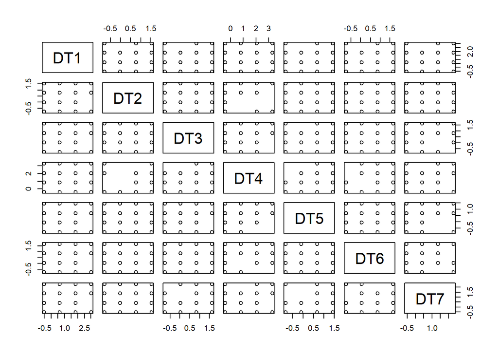

```r
mydata <- DavisThin
mydata <- na.omit(mydata)    # eliminacion NA's
mydata <- scale(mydata)      # estandarizacion de varibles, m=0, sd=1

pairs(mydata)
```

# Exercise 2: Hierarchical Clustering

There are four methods to measure distance between clusters:  
- **complete**: pairwise similarty between all observations in cluster 1 and 2, uses largest of similarities  
- **single**: same as above but uses the smallest of similarities  
- **average**: same as above but uses average of similarities  
- **centroid**: finds centroid of cluster 1 and 2, uses similarity between tow centroids

rule of thumb:  
**complete** and **average** produce more balanced treess and are more commonly used.  
**single** fuses observations in one at a time and produces more unblanced trees.  
**centroid** can create inversion where clusters are put below single values. its not used often.

```r
hclust.out <- hclust(dist(mydata, method = "euclidean"), method = "complete")

# Inspect the result
hclust.out
```

```
##
## Call:
## hclust(d = dist(mydata, method = "euclidean"), method = "complete")
##
## Cluster method   : complete
## Distance         : euclidean
## Number of objects: 191
```

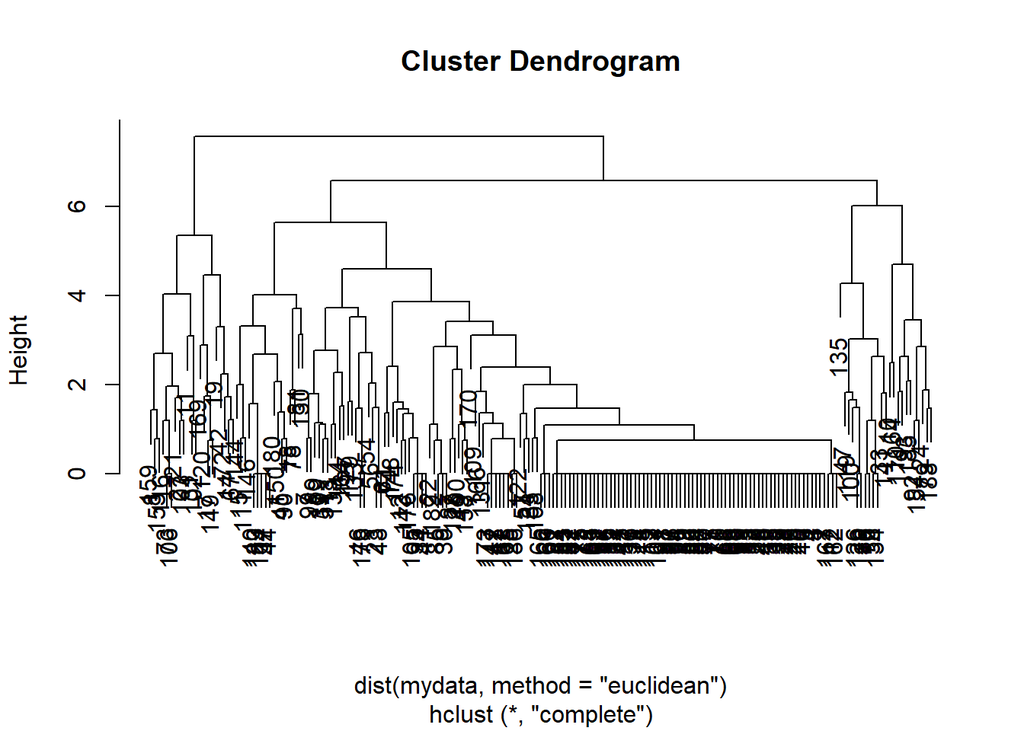

```r
# Plot hclust
plot(hclust.out)
```

De acuerdo con el dendograma, podriamos utilizar entre 5 y 7 clusters.

# Exercise 3: Selecting Number of Clusters (Cutting the tree)

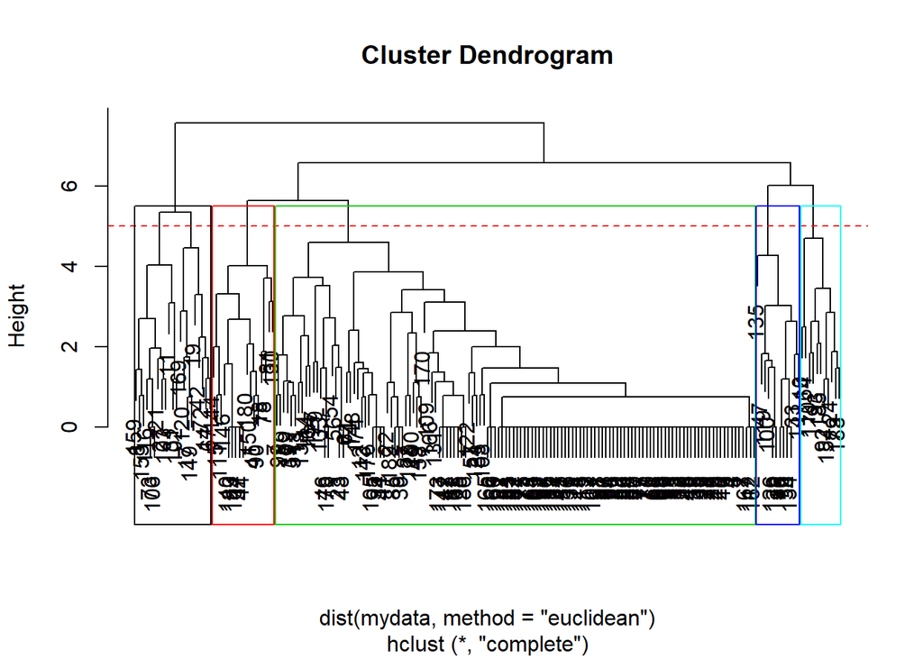

```r
plot(hclust.out)
abline(h = 5, col = "red", lty = 2)
rect.hclust(hclust.out, k = 5, border=1:5)
```

```r
# Cut by number of clusters
cut.hclust <- cutree(hclust.out, k = 5)
cut.hclust
```

```
##   1   2   3   4   5   6   7   8   9  10  11  12  13  14  15  16  17  18
##   1   1   1   1   1   1   1   2   1   3   2   1   1   2   4   1   2   4
##  19  20  21  22  23  24  25  26  27  28  29  30  31  32  33  34  35  36
##   2   1   2   1   1   3   1   1   2   1   1   1   2   1   5   1   1   5
##  37  38  39  40  41  42  43  44  45  46  47  48  49  50  51  52  53  54
##   4   1   1   1   1   2   1   4   4   1   5   1   1   1   1   1   1   1
##  55  56  57  58  59  60  61  62  63  64  65  66  67  68  69  70  71  72
##   1   1   1   5   1   1   1   1   1   3   1   1   2   1   1   1   1   2
##  73  74  75  76  77  78  79  80  81  82  83  84  85  86  87  88  89  90
##   2   1   1   5   1   4   3   1   4   1   1   1   1   1   1   1   1   4
##  91  92  93  94  95  96  97  98  99 100 101 102 103 104 105 106 107 108
##   1   3   3   1   1   1   1   1   1   5   1   2   2   4   1   2   1   1
## 109 110 111 112 113 114 115 116 117 118 119 120 121 122 123 124 125 126
##   1   3   4   1   1   1   1   2   1   1   5   2   1   1   4   1   1   5
## 127 128 129 130 131 132 133 134 135 136 137 138 139 140 141 142 143 144
##   1   1   5   4   1   1   1   5   5   1   1   1   1   4   5   1   1   4
## 145 146 147 148 149 150 151 152 153 154 155 156 157 158 159 160 161 162
##   1   4   1   1   2   4   1   1   2   3   1   1   1   1   2   1   1   1
## 163 164 165 166 167 168 169 170 171 172 173 174 175 176 177 178 179 180
##   1   1   1   1   1   1   2   1   3   1   1   1   1   1   1   1   1   4
## 181 182 183 184 185 186 187 188 189 190 191
##   1   1   1   1   3   1   1   3   1   1   1
```

# Exercise 4: Determining the Number of Clusters (k-means)

El algoritmo k-means (análisis no jerárquico) máximiza la homogéneidad dentro de los grupos y la heterogéneidad entre los grupos.

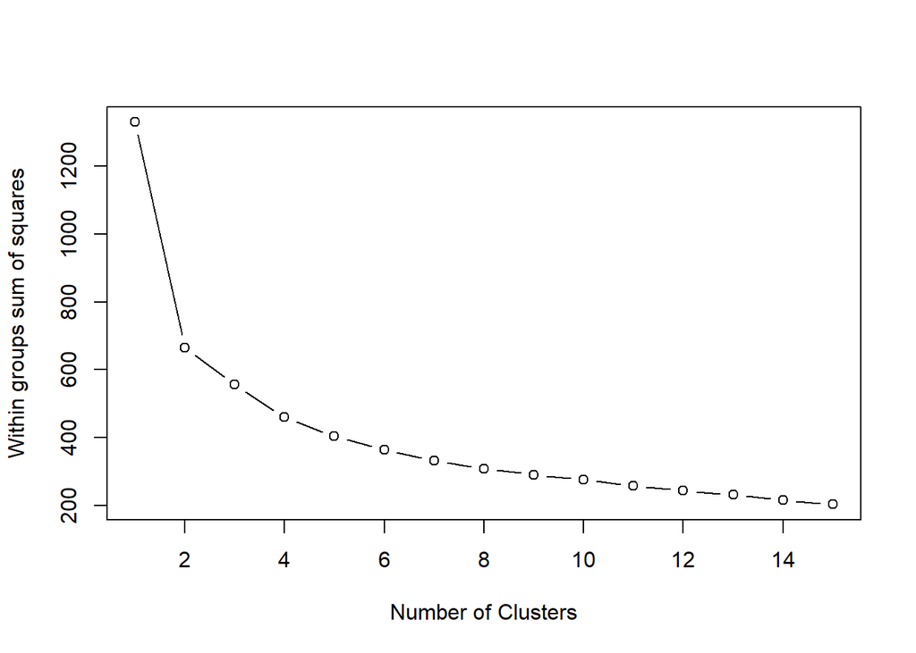

```r
# Initialize total within sum of squares error: wss
wss <- 0

# For 1 to 15 cluster centers
for (i in 1:15) {
  km.out <- kmeans(mydata, centers = i, nstart = 30)
  # Save total within sum of squares to wss variable
  wss[i] <- km.out$tot.withinss
}

# Plot total within sum of squares vs. number of clusters
plot(1:15, wss, type = "b",
     xlab = "Number of Clusters",
     ylab = "Within groups sum of squares")
```

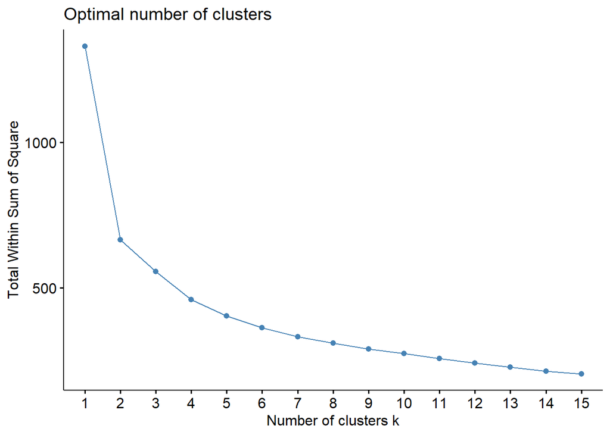

```r
# Usando factoextra
library(factoextra)
fviz_nbclust(x = mydata, FUNcluster = kmeans, method = "wss", k.max = 15,
             diss = get_dist(mydata, method = "euclidean"), nstart = 50)
```

De acuerdo con la grafica, podriamos utilizar entre 5 y 7 clusters.

# Exercise 5: Create the k-means model: km.out

```r
km.out1 <- kmeans(mydata, centers = 5, nstart = 15, algorithm = "Hartigan-Wong")
names(km.out1)
```

```
## [1] "cluster"      "centers"      "totss"        "withinss"
## [5] "tot.withinss" "betweenss"    "size"         "iter"
## [9] "ifault"
```

```r
# Print the km.out object
km.out
```

```
## K-means clustering with 15 clusters of sizes 12, 9, 6, 7, 12, 4, 6, 9, 8, 80, 9, 9, 4, 9, 7
##
## Cluster means:
##           DT1         DT2        DT3        DT4           DT5         DT6
## 1   1.5316692  1.28444314  1.6313390  2.6855146  1.3694814836  1.53345963
## 2  -0.5558351  1.11100473 -0.2328492 -0.1468443  0.1693249263  1.13021394
## 3   1.8298841  0.37389146  1.3650264 -0.4231720  0.9273185414  1.53345963
## 4  -0.3854266 -0.01634498  0.6041332 -0.2455328  0.7829388052  0.51574431
## 5   0.7364295 -0.60169964 -0.6988963 -0.4231720 -0.7781670927 -0.61718407
## 6   2.4263139 -0.60169964 -0.5657400 -0.4231720  0.6746540030 -0.75159931
## 7  -0.5558351  0.89420671  1.4981827  2.2710231  1.3063153490  0.86138347
## 8  -0.5558351 -0.79681786 -0.7654744 -0.1468443  0.6746540030  0.05489208
## 9   0.4879171  1.25192344  0.8324012 -0.2677377  1.4326476182  1.26462917
## 10 -0.5558351 -0.75779421 -0.7255276 -0.4231720 -0.8129084667 -0.73143702
## 11 -0.1582152  1.45788156  1.6313390 -0.2850082  1.4326476182  1.66787486
```

[output cut: 56 more lines]

```r
# Append cluster assignment
mydata.km <- data.frame(mydata, km.out1$cluster)
head(mydata.km, 10)
```

```
##           DT1         DT2        DT3        DT4        DT5        DT6
## 1  -0.5558351 -0.79681786 -0.7654744 -0.4231720 -0.8413332 -0.7515993
## 2  -0.5558351 -0.79681786 -0.7654744 -0.4231720 -0.8413332 -0.7515993
## 3  -0.5558351 -0.79681786 -0.7654744 -0.4231720 -0.8413332 -0.7515993
## 4  -0.5558351 -0.79681786 -0.7654744 -0.4231720 -0.8413332 -0.7515993
## 5  -0.5558351 -0.79681786 -0.7654744 -0.4231720 -0.8413332 -0.7515993
## 6  -0.5558351 -0.01634498 -0.7654744 -0.4231720 -0.8413332 -0.7515993
## 7  -0.5558351  0.76412789  0.8324012 -0.4231720  0.6746540  0.8613835
## 8   1.8298841  1.54460077  1.6313390  2.0637773  1.4326476  1.6678749
## 9  -0.5558351 -0.79681786 -0.7654744 -0.4231720  1.4326476 -0.7515993
## 10  3.0227437  1.54460077  0.8324012  0.8203027  1.4326476  1.6678749
##          DT7 km.out1.cluster
## 1  -0.536656               5
## 2  -0.536656               5
## 3  -0.536656               5
## 4  -0.536656               5
## 5  -0.536656               5
## 6  -0.536656               5
## 7  -0.536656               2
## 8   2.310602               3
## 9  -0.536656               2
## 10 -0.536656               3
```

# Exercise 6: Visualizing and interpreting results of kmeans()

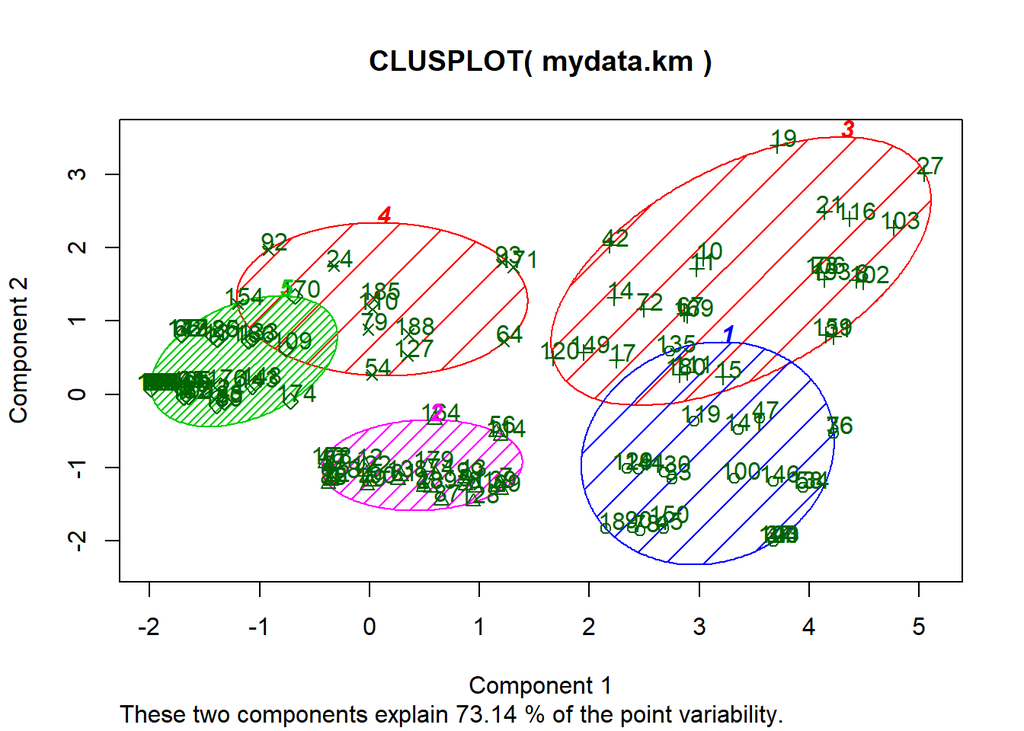

```r
# Scatter plot
clusplot(mydata.km, km.out1$cluster, color=T, shade=T, labels=2, lines=0)
```

```r
#ggplot(data = mydata, aes(x = x, y = y, color = km.out1$cluster)) + geom_point(size = 2.5) + theme_bw()
```

# Exercise 7: Comparing kmeans() and hclust()

```r
table(km.out1$cluster, cut.hclust)
```

```
##    cut.hclust
##      1  2  3  4  5
##   1  0  0  0 13 12
##   2 30  0  0  1  0
##   3  0 21  1  3  0
##   4  2  0 10  0  0
##   5 98  0  0  0  0
```